# Dann machen wir das gleich ordentlich!

Vorhandene Projekte entdecken

R. Dutschke, C. Scheffel, M. Schoemann, G. Thiele

## Praxisbeispiel 1: RMarkdown Kurs für Promovierende

[figure not shown]

https://github.com/alex-strobel/R-Markdown

## Praxisbeispiel 1: RMarkdown Kurs für Promovierende

Kurs für Promovierende um den Umgang mit RMarkdown zu erlernen. Dabei gibt es verschiedene Lektionen, in denen jeweils grundlegende Funktionen / Nutzung vermittelt wird und anschließend die gelernten Aspekte in Übungen praktisch ausprobiert werden sollen. Prinzipiell würde sich das Repositorium auch eignen, um den Workshop remote, bzw. self-paced durchzuführen.

Worauf haben wir Wert gelegt?

- Ordnerstruktur entspricht Struktur der Lektionen und kann mittels GitHub übergeben werdenn.
- Übergabe von Scripten an Promovierende, die einerseits Erklärungen enthalten, andererseits, aber direkt weiter bearbeitet werden können
- Branching: Während des Erstellens des Kurses konnten verschiedene Personen parallel an verschiedenen Lektionen und Scripten arbeiten
- Forking: Repositorium soll im Grundzustand erhalten bleiben, damit es für künftige Kurse immer genutzt werden kann. Gleichzeitig sollen aber alle Teilnehmenden an ihren eigenen Dateien arbeiten können (ohne, dass die anderen Teilnehmenden ihre Lösungen sehen und ohne, dass das Repositorium verändert wird).

## Praxisbeispiel 2: Kollaborative Entwicklung von Lehrmaterialien

- Verwaltung von Lehrmaterialien in einem Seminar mit mehreren Dozierenden (Alternative zu Cloudstorage)
- Einsicht auf Nachfrage

Worauf haben wir Wert gelegt?

- gemeinsame und sinnvolle Ordnerstruktur
- gemeinsame Nutzung von Materialien bei individueller Foliengestaltung
- semesterübergreifende Bearbeitung ist ohne Dateienredundanz möglich (checkout alter Commits jederzeit möglich)

[figure not shown]

## Praxisbeispiel 3: Betreuung einer Abschlussarbeit

Die Abschlussarbeit hat sich mit einer Teilfragestellung unserer Studie befasst. Initial war die Idee, das Repositorium zu klonen, unser Study hat es am Ende geforkt und wir waren Mitglieder in seinem Repo und konnten Materialien für Code Review und Feedback darüber abrufen.

Worauf haben wir Wert gelegt?

- die Ordnerstruktur war von uns vorgegeben und hat sich an der Studie orientiert
- bestehende Analyseskripte, die unser Study nutzen sollte, waren bereits vorhanden
- Rücktransfer von Code in das Studienrepositorium per Pull Request möglich
- Studienrepositorium wurde nicht von der Fork beeinflusst

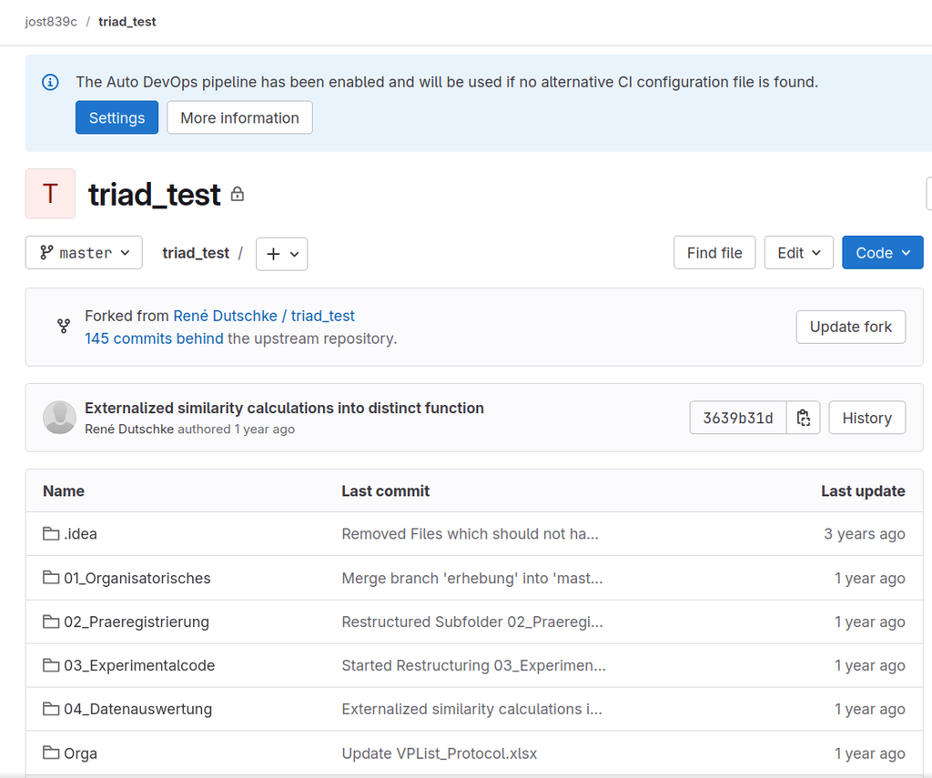